# FML-Assignment 4

2024-03-15

## Loading libararies and data

```r
library(tidyverse)
library(factoextra)
library(flexclust)
library(reshape2)
```

```r
library(cowplot)

set.seed(123)

data <- read.csv("C:/Users/John/Documents/Pharmaceuticals.csv")
row.names(data) <- data[,2]

df <- data[, 3:11] # grabbing only the numeric variables
head(df)
```

```
##                     Market_Cap Beta PE_Ratio  ROE  ROA Asset_Turnover Leverage
## Abbott Laboratories      68.44 0.32     24.7 26.4 11.8            0.7     0.42
## Allergan, Inc.            7.58 0.41     82.5 12.9  5.5            0.9     0.60
## Amersham plc              6.30 0.46     20.7 14.9  7.8            0.9     0.27
## AstraZeneca PLC          67.63 0.52     21.5 27.4 15.4            0.9     0.00
## Aventis                  47.16 0.32     20.1 21.8  7.5            0.6     0.34
## Bayer AG                 16.90 1.11     27.9  3.9  1.4            0.6     0.00
##                     Rev_Growth Net_Profit_Margin
## Abbott Laboratories       7.54              16.1
## Allergan, Inc.            9.16               5.5
## Amersham plc              7.05              11.2
## AstraZeneca PLC          15.00              18.0
## Aventis                  26.81              12.9
## Bayer AG                 -3.17               2.6
```

## Use only the numerical variables (1 to 9) to cluster the 21 firms. Justify the various choices made in conducting the cluster analysis, such as weights for different variables, the specific clustering algorithm(s)

used, the number of clusters formed, and so on.

Normalizing numerical variables

```r
df <- scale(df)
summary(df)
```

```
##    Market_Cap           Beta            PE_Ratio            ROE
##  Min.   :-0.9768   Min.   :-1.3466   Min.   :-1.3404   Min.   :-1.4515
##  1st Qu.:-0.8763   1st Qu.:-0.6844   1st Qu.:-0.4023   1st Qu.:-0.7223
##  Median :-0.1614   Median :-0.2560   Median :-0.2429   Median :-0.2118
##  Mean   : 0.0000   Mean   : 0.0000   Mean   : 0.0000   Mean   : 0.0000
##  3rd Qu.: 0.2762   3rd Qu.: 0.4841   3rd Qu.: 0.1495   3rd Qu.: 0.3450
##  Max.   : 2.4200   Max.   : 2.2758   Max.   : 3.4971   Max.   : 2.4597
##       ROA          Asset_Turnover       Leverage          Rev_Growth
##  Min.   :-1.7128   Min.   :-1.8451   Min.   :-0.74966   Min.   :-1.4971
##  1st Qu.:-0.9047   1st Qu.:-0.4613   1st Qu.:-0.54487   1st Qu.:-0.6328
##  Median : 0.1289   Median :-0.4613   Median :-0.31449   Median :-0.3621
##  Mean   : 0.0000   Mean   : 0.0000   Mean   : 0.00000   Mean   : 0.0000
##  3rd Qu.: 0.8430   3rd Qu.: 0.9225   3rd Qu.: 0.01828   3rd Qu.: 0.7693
##  Max.   : 1.8389   Max.   : 1.8451   Max.   : 3.74280   Max.   : 1.8862
##  Net_Profit_Margin
##  Min.   :-1.99560
##  1st Qu.:-0.68504
##  Median : 0.06168
##  Mean   : 0.00000
##  3rd Qu.: 0.82364
##  Max.   : 1.49416
```

Elbow and silhouette method

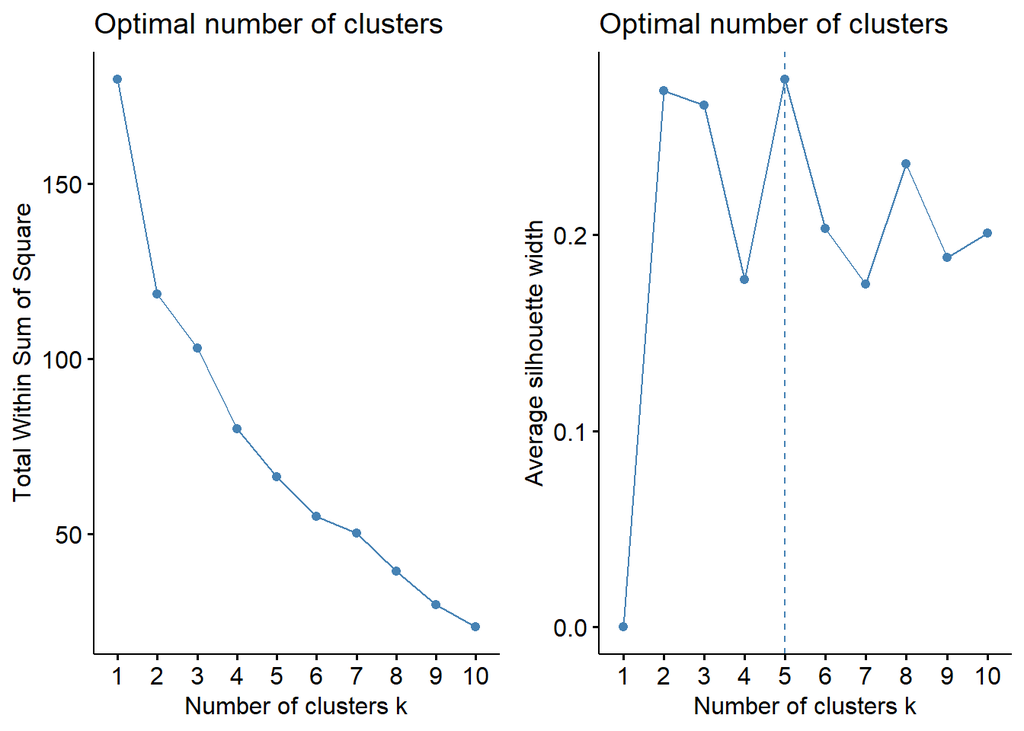

```r
wss <- fviz_nbclust(df, kmeans, method = "wss")
sil <- fviz_nbclust(df, kmeans, method = "silhouette")

plot_grid(wss, sil)
```

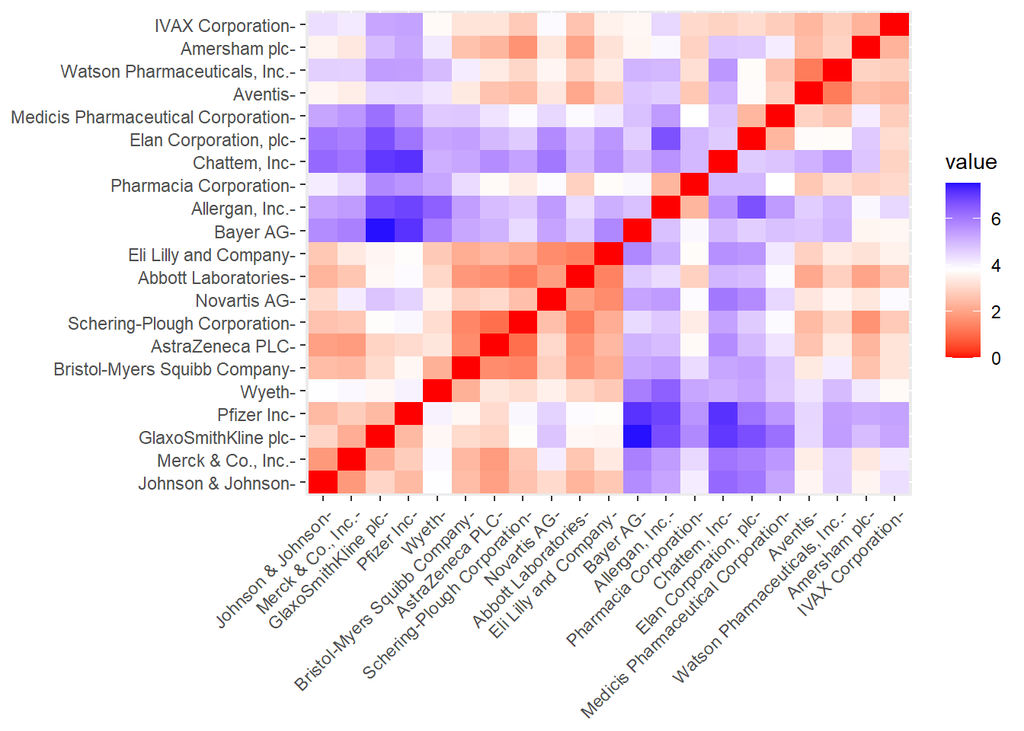

```r
distance <- get_dist(df)
fviz_dist(distance)
```

Running k-mean

```r
set.seed(123)

k5 <- kmeans(df, 5, nstart = 25)
```

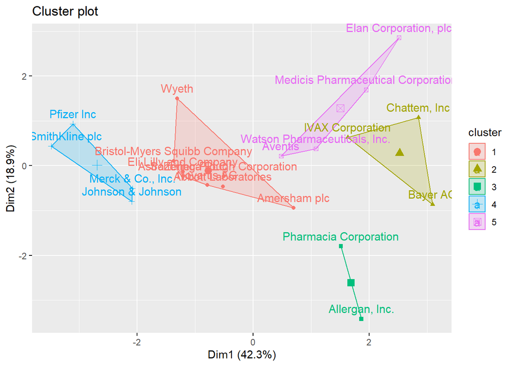

```r
fviz_cluster(k5, df)
```

A visual representation of the clusters.

## b. Interpret the clusters with respect to the numerical variables used in forming the clusters.

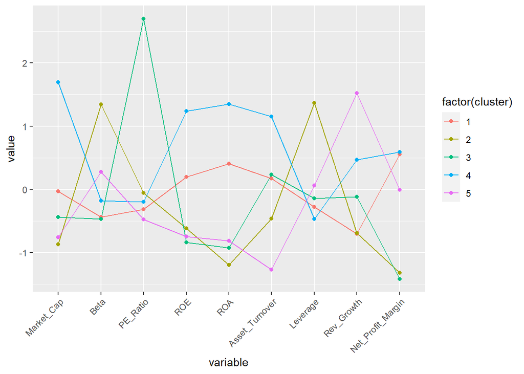

```r
centers <- k5$centers
centers <- as.data.frame(centers)
centers$cluster <- 1:nrow(centers)
centers_long <- melt(centers, id.vars = "cluster")

ggplot(centers_long, aes(x = variable, y = value, color = factor(cluster))) + # using a factor for color makes sure the legend is not a gradient
  geom_line(aes(group = as.factor(cluster))) + geom_point() +
  theme(axis.text.x = element_text(angle = 45, hjust = 1)) # rotates the x values for readability
```

With this visualization we can see the characteristic of each variable that make up each cluster.

```r
k5$size
```

```
## [1] 8 3 2 4 4
```

Here you can see the number of firms in each cluster

## c. Is there a pattern in the clusters with respect to the numerical variables (10 to 12)?

```r
data_cluster <- data %>%
  mutate(cluster = k5$cluster) # adds a "cluster" column to label what cluster each company is within.
```

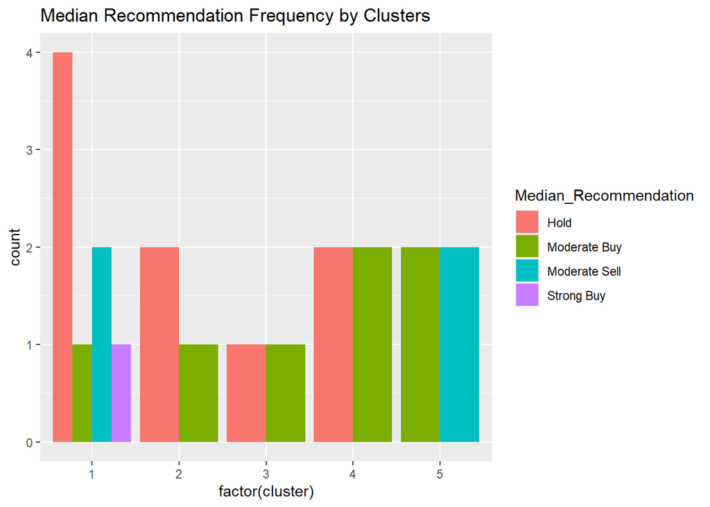

```r
ggplot(data_cluster, mapping = aes(factor(cluster), fill=Median_Recommendation)) +
  geom_bar(position = 'dodge') +
  ggtitle("Median Recommendation Frequency by Clusters")
```

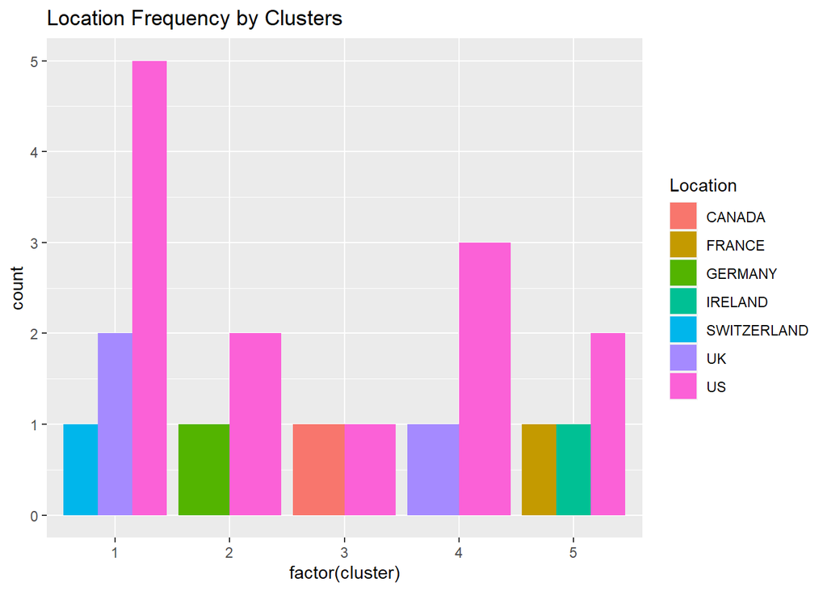

```r
ggplot(data_cluster, mapping = aes(factor(cluster), fill=Location)) +
  geom_bar(position = 'dodge') +
  ggtitle("Location Frequency by Clusters")
```

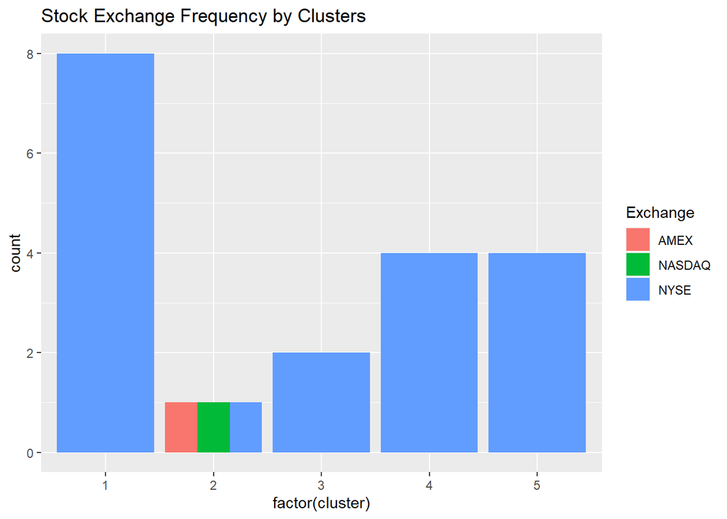

```r
ggplot(data_cluster, mapping = aes(factor(cluster), fill=Exchange)) +
  geom_bar(position = 'dodge') +
  ggtitle("Stock Exchange Frequency by Clusters")
```

With these three visuals, we can see the frequencies of columns 12:14. These can help us visualize the clear skew towards US locations and dominance of NYSE.

## d. Provide an appropriate name for each cluster using any or all of the variables in the dataset

Cluster 1: This cluster could be called “Growing Pharmaceutical Companies” This is because they have a relatively high count of “moderate sell” and “hold”, which tell us that the stock high but still likely growing.

Cluster 2: This cluster could be called “Small Pharmaceutical Companies.” These companies are made up of “Hold”, “Moderate Buy” and high leverage, indicating that the stock is not overvalued and is somewhat likely to grow.

Cluster 5: This cluster could be called “High Revenue Growth.” These companies have a surprising combination of low asset turnover and high rev growth, which seems at odds with eachother. This could be why the recommendations are a split between moderate buy and moderate sell.

## Conclusion

If I were to run this again and I was not trying show the use of the silhouette method and the elbow method, I would have selected 3 or 4 clusters. I think this makes the clusters much easier to interpret and doesnt leave us with extremely small clusters like we see here with cluster 3.